# Optimal Treatment Analysis

## Outcome Variable

**Outcome Variable:** ever_wasted

## Predictor Variables

**Intervention Variable:** birthwt

**Adjustment Set:**

- arm
- sex
- W_mage
- meducyrs
- feducyrs
- vagbrth
- single
- brthmon
- W_parity
- delta_W_mage
- delta_meducyrs
- delta_feducyrs
- delta_vagbrth
- delta_single
- delta_brthmon
- delta_W_parity

## Stratifying Variables

The analysis was stratified on these variable(s):

- agecat
- studyid
- country

## Data Summary

| agecat | studyid | country | birthwt | ever_wasted | n_cell | n |
| --- | --- | --- | --- | --- | --- | --- |
| 0-24 months (no birth wast) | ki0047075b-MAL-ED | BANGLADESH | Normal or high birthweight | 0 | 164 | 255 |
| 0-24 months (no birth wast) | ki0047075b-MAL-ED | BANGLADESH | Normal or high birthweight | 1 | 39 | 255 |
| 0-24 months (no birth wast) | ki0047075b-MAL-ED | BANGLADESH | Low birth weight | 0 | 35 | 255 |
| 0-24 months (no birth wast) | ki0047075b-MAL-ED | BANGLADESH | Low birth weight | 1 | 17 | 255 |
| 0-24 months (no birth wast) | ki0047075b-MAL-ED | BRAZIL | Normal or high birthweight | 0 | 206 | 229 |
| 0-24 months (no birth wast) | ki0047075b-MAL-ED | BRAZIL | Normal or high birthweight | 1 | 11 | 229 |
| 0-24 months (no birth wast) | ki0047075b-MAL-ED | BRAZIL | Low birth weight | 0 | 11 | 229 |
| 0-24 months (no birth wast) | ki0047075b-MAL-ED | BRAZIL | Low birth weight | 1 | 1 | 229 |
| 0-24 months (no birth wast) | ki0047075b-MAL-ED | INDIA | Normal or high birthweight | 0 | 133 | 234 |
| 0-24 months (no birth wast) | ki0047075b-MAL-ED | INDIA | Normal or high birthweight | 1 | 65 | 234 |
| 0-24 months (no birth wast) | ki0047075b-MAL-ED | INDIA | Low birth weight | 0 | 16 | 234 |
| 0-24 months (no birth wast) | ki0047075b-MAL-ED | INDIA | Low birth weight | 1 | 20 | 234 |
| 0-24 months (no birth wast) | ki0047075b-MAL-ED | NEPAL | Normal or high birthweight | 0 | 175 | 231 |
| 0-24 months (no birth wast) | ki0047075b-MAL-ED | NEPAL | Normal or high birthweight | 1 | 35 | 231 |
| 0-24 months (no birth wast) | ki0047075b-MAL-ED | NEPAL | Low birth weight | 0 | 15 | 231 |
| 0-24 months (no birth wast) | ki0047075b-MAL-ED | NEPAL | Low birth weight | 1 | 6 | 231 |
| 0-24 months (no birth wast) | ki0047075b-MAL-ED | PERU | Normal or high birthweight | 0 | 263 | 296 |
| 0-24 months (no birth wast) | ki0047075b-MAL-ED | PERU | Normal or high birthweight | 1 | 15 | 296 |
| 0-24 months (no birth wast) | ki0047075b-MAL-ED | PERU | Low birth weight | 0 | 13 | 296 |
| 0-24 months (no birth wast) | ki0047075b-MAL-ED | PERU | Low birth weight | 1 | 5 | 296 |
| 0-24 months (no birth wast) | ki0047075b-MAL-ED | SOUTH AFRICA | Normal or high birthweight | 0 | 235 | 294 |
| 0-24 months (no birth wast) | ki0047075b-MAL-ED | SOUTH AFRICA | Normal or high birthweight | 1 | 39 | 294 |
| 0-24 months (no birth wast) | ki0047075b-MAL-ED | SOUTH AFRICA | Low birth weight | 0 | 15 | 294 |
| 0-24 months (no birth wast) | ki0047075b-MAL-ED | SOUTH AFRICA | Low birth weight | 1 | 5 | 294 |
| 0-24 months (no birth wast) | ki0047075b-MAL-ED | TANZANIA, UNITED REPUBLIC OF | Normal or high birthweight | 0 | 115 | 135 |
| 0-24 months (no birth wast) | ki0047075b-MAL-ED | TANZANIA, UNITED REPUBLIC OF | Normal or high birthweight | 1 | 13 | 135 |
| 0-24 months (no birth wast) | ki0047075b-MAL-ED | TANZANIA, UNITED REPUBLIC OF | Low birth weight | 0 | 6 | 135 |
| 0-24 months (no birth wast) | ki0047075b-MAL-ED | TANZANIA, UNITED REPUBLIC OF | Low birth weight | 1 | 1 | 135 |
| 0-24 months (no birth wast) | ki1000108-CMC-V-BCS-2002 | INDIA | Normal or high birthweight | 0 | 185 | 368 |
| 0-24 months (no birth wast) | ki1000108-CMC-V-BCS-2002 | INDIA | Normal or high birthweight | 1 | 143 | 368 |

[output cut: 318 more lines]

The following strata were considered:

- agecat: 0-24 months (no birth wast), studyid: ki0047075b-MAL-ED, country: BANGLADESH
- agecat: 0-24 months (no birth wast), studyid: ki0047075b-MAL-ED, country: BRAZIL
- agecat: 0-24 months (no birth wast), studyid: ki0047075b-MAL-ED, country: INDIA
- agecat: 0-24 months (no birth wast), studyid: ki0047075b-MAL-ED, country: NEPAL
- agecat: 0-24 months (no birth wast), studyid: ki0047075b-MAL-ED, country: PERU
- agecat: 0-24 months (no birth wast), studyid: ki0047075b-MAL-ED, country: SOUTH AFRICA
- agecat: 0-24 months (no birth wast), studyid: ki0047075b-MAL-ED, country: TANZANIA, UNITED REPUBLIC OF
- agecat: 0-24 months (no birth wast), studyid: ki1000108-CMC-V-BCS-2002, country: INDIA
- agecat: 0-24 months (no birth wast), studyid: ki1000108-IRC, country: INDIA
- agecat: 0-24 months (no birth wast), studyid: ki1000109-EE, country: PAKISTAN
- agecat: 0-24 months (no birth wast), studyid: ki1000109-ResPak, country: PAKISTAN
- agecat: 0-24 months (no birth wast), studyid: ki1000304b-SAS-CompFeed, country: INDIA
- agecat: 0-24 months (no birth wast), studyid: ki1017093-NIH-Birth, country: BANGLADESH
- agecat: 0-24 months (no birth wast), studyid: ki1017093b-PROVIDE, country: BANGLADESH
- agecat: 0-24 months (no birth wast), studyid: ki1017093c-NIH-Crypto, country: BANGLADESH
- agecat: 0-24 months (no birth wast), studyid: ki1066203-TanzaniaChild2, country: TANZANIA, UNITED REPUBLIC OF
- agecat: 0-24 months (no birth wast), studyid: ki1101329-Keneba, country: GAMBIA
- agecat: 0-24 months (no birth wast), studyid: ki1114097-CMIN, country: BANGLADESH
- agecat: 0-24 months (no birth wast), studyid: ki1114097-CMIN, country: BRAZIL
- agecat: 0-24 months (no birth wast), studyid: ki1114097-CMIN, country: GUINEA-BISSAU
- agecat: 0-24 months (no birth wast), studyid: ki1114097-CMIN, country: PERU
- agecat: 0-24 months (no birth wast), studyid: ki1114097-CONTENT, country: PERU
- agecat: 0-24 months (no birth wast), studyid: ki1119695-PROBIT, country: BELARUS
- agecat: 0-24 months (no birth wast), studyid: ki1126311-ZVITAMBO, country: ZIMBABWE
- agecat: 0-24 months (no birth wast), studyid: ki1135781-COHORTS, country: GUATEMALA
- agecat: 0-24 months (no birth wast), studyid: ki1135781-COHORTS, country: INDIA
- agecat: 0-24 months (no birth wast), studyid: ki1135781-COHORTS, country: PHILIPPINES
- agecat: 0-24 months (no birth wast), studyid: kiGH5241-JiVitA-3, country: BANGLADESH
- agecat: 0-24 months (no birth wast), studyid: kiGH5241-JiVitA-4, country: BANGLADESH
- agecat: 0-6 months (no birth wast), studyid: ki0047075b-MAL-ED, country: BANGLADESH
- agecat: 0-6 months (no birth wast), studyid: ki0047075b-MAL-ED, country: BRAZIL
- agecat: 0-6 months (no birth wast), studyid: ki0047075b-MAL-ED, country: INDIA
- agecat: 0-6 months (no birth wast), studyid: ki0047075b-MAL-ED, country: NEPAL
- agecat: 0-6 months (no birth wast), studyid: ki0047075b-MAL-ED, country: PERU
- agecat: 0-6 months (no birth wast), studyid: ki0047075b-MAL-ED, country: SOUTH AFRICA
- agecat: 0-6 months (no birth wast), studyid: ki0047075b-MAL-ED, country: TANZANIA, UNITED REPUBLIC OF
- agecat: 0-6 months (no birth wast), studyid: ki1000108-CMC-V-BCS-2002, country: INDIA
- agecat: 0-6 months (no birth wast), studyid: ki1000108-IRC, country: INDIA
- agecat: 0-6 months (no birth wast), studyid: ki1000109-EE, country: PAKISTAN
- agecat: 0-6 months (no birth wast), studyid: ki1000109-ResPak, country: PAKISTAN
- agecat: 0-6 months (no birth wast), studyid: ki1000304b-SAS-CompFeed, country: INDIA
- agecat: 0-6 months (no birth wast), studyid: ki1017093-NIH-Birth, country: BANGLADESH
- agecat: 0-6 months (no birth wast), studyid: ki1017093b-PROVIDE, country: BANGLADESH
- agecat: 0-6 months (no birth wast), studyid: ki1017093c-NIH-Crypto, country: BANGLADESH
- agecat: 0-6 months (no birth wast), studyid: ki1066203-TanzaniaChild2, country: TANZANIA, UNITED REPUBLIC OF
- agecat: 0-6 months (no birth wast), studyid: ki1101329-Keneba, country: GAMBIA
- agecat: 0-6 months (no birth wast), studyid: ki1114097-CMIN, country: BANGLADESH
- agecat: 0-6 months (no birth wast), studyid: ki1114097-CMIN, country: BRAZIL
- agecat: 0-6 months (no birth wast), studyid: ki1114097-CMIN, country: GUINEA-BISSAU
- agecat: 0-6 months (no birth wast), studyid: ki1114097-CMIN, country: PERU
- agecat: 0-6 months (no birth wast), studyid: ki1114097-CONTENT, country: PERU
- agecat: 0-6 months (no birth wast), studyid: ki1119695-PROBIT, country: BELARUS
- agecat: 0-6 months (no birth wast), studyid: ki1126311-ZVITAMBO, country: ZIMBABWE
- agecat: 0-6 months (no birth wast), studyid: ki1135781-COHORTS, country: GUATEMALA
- agecat: 0-6 months (no birth wast), studyid: ki1135781-COHORTS, country: INDIA
- agecat: 0-6 months (no birth wast), studyid: ki1135781-COHORTS, country: PHILIPPINES
- agecat: 0-6 months (no birth wast), studyid: kiGH5241-JiVitA-3, country: BANGLADESH
- agecat: 0-6 months (no birth wast), studyid: kiGH5241-JiVitA-4, country: BANGLADESH
- agecat: 6-24 months, studyid: ki0047075b-MAL-ED, country: BANGLADESH
- agecat: 6-24 months, studyid: ki0047075b-MAL-ED, country: BRAZIL
- agecat: 6-24 months, studyid: ki0047075b-MAL-ED, country: INDIA
- agecat: 6-24 months, studyid: ki0047075b-MAL-ED, country: NEPAL
- agecat: 6-24 months, studyid: ki0047075b-MAL-ED, country: PERU
- agecat: 6-24 months, studyid: ki0047075b-MAL-ED, country: SOUTH AFRICA
- agecat: 6-24 months, studyid: ki0047075b-MAL-ED, country: TANZANIA, UNITED REPUBLIC OF
- agecat: 6-24 months, studyid: ki1000108-CMC-V-BCS-2002, country: INDIA
- agecat: 6-24 months, studyid: ki1000108-IRC, country: INDIA
- agecat: 6-24 months, studyid: ki1000109-EE, country: PAKISTAN
- agecat: 6-24 months, studyid: ki1000109-ResPak, country: PAKISTAN
- agecat: 6-24 months, studyid: ki1000304b-SAS-CompFeed, country: INDIA
- agecat: 6-24 months, studyid: ki1017093-NIH-Birth, country: BANGLADESH
- agecat: 6-24 months, studyid: ki1017093b-PROVIDE, country: BANGLADESH
- agecat: 6-24 months, studyid: ki1017093c-NIH-Crypto, country: BANGLADESH
- agecat: 6-24 months, studyid: ki1066203-TanzaniaChild2, country: TANZANIA, UNITED REPUBLIC OF
- agecat: 6-24 months, studyid: ki1101329-Keneba, country: GAMBIA
- agecat: 6-24 months, studyid: ki1114097-CMIN, country: BANGLADESH
- agecat: 6-24 months, studyid: ki1114097-CMIN, country: BRAZIL
- agecat: 6-24 months, studyid: ki1114097-CMIN, country: GUINEA-BISSAU
- agecat: 6-24 months, studyid: ki1114097-CMIN, country: PERU
- agecat: 6-24 months, studyid: ki1114097-CONTENT, country: PERU
- agecat: 6-24 months, studyid: ki1119695-PROBIT, country: BELARUS
- agecat: 6-24 months, studyid: ki1126311-ZVITAMBO, country: ZIMBABWE
- agecat: 6-24 months, studyid: ki1135781-COHORTS, country: GUATEMALA
- agecat: 6-24 months, studyid: ki1135781-COHORTS, country: INDIA
- agecat: 6-24 months, studyid: ki1135781-COHORTS, country: PHILIPPINES
- agecat: 6-24 months, studyid: kiGH5241-JiVitA-3, country: BANGLADESH
- agecat: 6-24 months, studyid: kiGH5241-JiVitA-4, country: BANGLADESH

### Dropped Strata

Some strata were dropped due to rare outcomes:

- agecat: 0-24 months (no birth wast), studyid: ki0047075b-MAL-ED, country: BRAZIL
- agecat: 0-24 months (no birth wast), studyid: ki0047075b-MAL-ED, country: TANZANIA, UNITED REPUBLIC OF
- agecat: 0-24 months (no birth wast), studyid: ki1000109-ResPak, country: PAKISTAN
- agecat: 0-24 months (no birth wast), studyid: ki1114097-CMIN, country: BANGLADESH
- agecat: 0-24 months (no birth wast), studyid: ki1114097-CMIN, country: BRAZIL
- agecat: 0-24 months (no birth wast), studyid: ki1114097-CMIN, country: GUINEA-BISSAU
- agecat: 0-24 months (no birth wast), studyid: ki1114097-CMIN, country: PERU
- agecat: 0-24 months (no birth wast), studyid: ki1114097-CONTENT, country: PERU
- agecat: 0-24 months (no birth wast), studyid: ki1119695-PROBIT, country: BELARUS
- agecat: 0-6 months (no birth wast), studyid: ki0047075b-MAL-ED, country: BANGLADESH
- agecat: 0-6 months (no birth wast), studyid: ki0047075b-MAL-ED, country: BRAZIL
- agecat: 0-6 months (no birth wast), studyid: ki0047075b-MAL-ED, country: INDIA
- agecat: 0-6 months (no birth wast), studyid: ki0047075b-MAL-ED, country: NEPAL
- agecat: 0-6 months (no birth wast), studyid: ki0047075b-MAL-ED, country: PERU
- agecat: 0-6 months (no birth wast), studyid: ki0047075b-MAL-ED, country: SOUTH AFRICA
- agecat: 0-6 months (no birth wast), studyid: ki0047075b-MAL-ED, country: TANZANIA, UNITED REPUBLIC OF
- agecat: 0-6 months (no birth wast), studyid: ki1000109-ResPak, country: PAKISTAN
- agecat: 0-6 months (no birth wast), studyid: ki1017093c-NIH-Crypto, country: BANGLADESH
- agecat: 0-6 months (no birth wast), studyid: ki1114097-CMIN, country: BANGLADESH
- agecat: 0-6 months (no birth wast), studyid: ki1114097-CMIN, country: BRAZIL
- agecat: 0-6 months (no birth wast), studyid: ki1114097-CMIN, country: GUINEA-BISSAU
- agecat: 0-6 months (no birth wast), studyid: ki1114097-CMIN, country: PERU
- agecat: 0-6 months (no birth wast), studyid: ki1114097-CONTENT, country: PERU
- agecat: 0-6 months (no birth wast), studyid: ki1119695-PROBIT, country: BELARUS
- agecat: 0-6 months (no birth wast), studyid: ki1135781-COHORTS, country: GUATEMALA
- agecat: 6-24 months, studyid: ki0047075b-MAL-ED, country: BRAZIL
- agecat: 6-24 months, studyid: ki0047075b-MAL-ED, country: PERU
- agecat: 6-24 months, studyid: ki0047075b-MAL-ED, country: TANZANIA, UNITED REPUBLIC OF
- agecat: 6-24 months, studyid: ki1000109-ResPak, country: PAKISTAN
- agecat: 6-24 months, studyid: ki1114097-CMIN, country: BANGLADESH
- agecat: 6-24 months, studyid: ki1114097-CMIN, country: BRAZIL
- agecat: 6-24 months, studyid: ki1114097-CMIN, country: GUINEA-BISSAU
- agecat: 6-24 months, studyid: ki1114097-CMIN, country: PERU
- agecat: 6-24 months, studyid: ki1114097-CONTENT, country: PERU
- agecat: 6-24 months, studyid: ki1119695-PROBIT, country: BELARUS

## Methods Detail

We’re interested in the causal parameters $E[Y_a]$ for all values of $a \in \mathcal{A}$. These parameters represent the mean outcome if, possibly contrary to fact, we intervened to set all units to have $A=a$. Under the randomization and positivity assumptions, these are identified by the statistical parameters $\psi_a=E_W[E_{Y|A,W}(Y|A=a,W)]$. In addition, we’re interested in the mean of $Y$, $E[Y]$ under no intervention (the observed mean). We will estimate these parameters by using SuperLearner to fit the relevant likelihood factors – $E_{Y|A,W}(Y|A=a,W)$ and $p(A=a|W)$, and then updating our likelihood fit using a joint TMLE.

For unadjusted analyses ($W=\{\}$), initial likelihoods were estimated using Lrnr_glm to estimate the simple $E(Y|A)$ and Lrnr_mean to estimate $p(A)$. For adjusted analyses, a small library containing Lrnr_glmnet, Lrnr_xgboost, and Lrnr_mean was used.

Having estimated these parameters, we will then use the delta method to estimate relative risks and attributable risks relative to a prespecified baseline level of $A$.

# Results Detail

## Results Plots

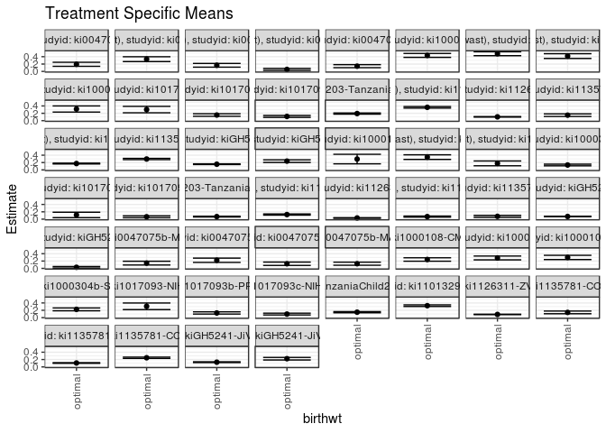

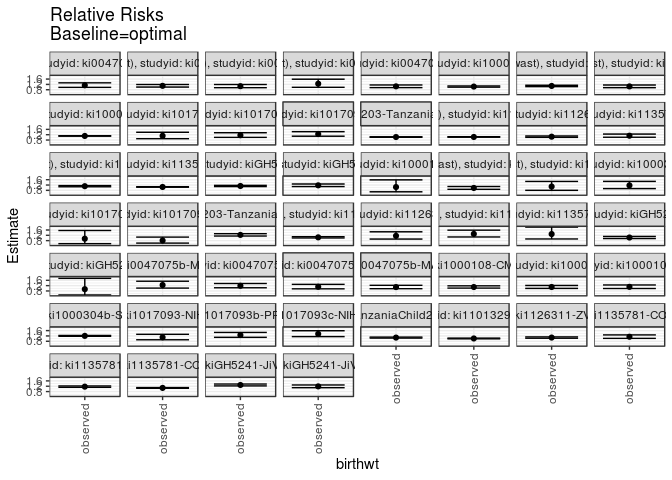

## Results Table

### Parameter: TSM

| agecat | studyid | country | intervention_level | baseline_level | estimate | ci_lower | ci_upper |
| --- | --- | --- | --- | --- | --- | --- | --- |
| 0-24 months (no birth wast) | ki0047075b-MAL-ED | BANGLADESH | optimal | NA | 0.1936243 | 0.1390404 | 0.2482082 |
| 0-24 months (no birth wast) | ki0047075b-MAL-ED | INDIA | optimal | NA | 0.3329700 | 0.2673808 | 0.3985592 |
| 0-24 months (no birth wast) | ki0047075b-MAL-ED | NEPAL | optimal | NA | 0.1664487 | 0.1159285 | 0.2169689 |
| 0-24 months (no birth wast) | ki0047075b-MAL-ED | PERU | optimal | NA | 0.0540602 | 0.0274256 | 0.0806947 |
| 0-24 months (no birth wast) | ki0047075b-MAL-ED | SOUTH AFRICA | optimal | NA | 0.1421794 | 0.1007362 | 0.1836226 |
| 0-24 months (no birth wast) | ki1000108-CMC-V-BCS-2002 | INDIA | optimal | NA | 0.4353966 | 0.3816294 | 0.4891639 |
| 0-24 months (no birth wast) | ki1000108-IRC | INDIA | optimal | NA | 0.4811233 | 0.4277658 | 0.5344808 |
| 0-24 months (no birth wast) | ki1000109-EE | PAKISTAN | optimal | NA | 0.4169480 | 0.3524274 | 0.4814685 |
| 0-24 months (no birth wast) | ki1000304b-SAS-CompFeed | INDIA | optimal | NA | 0.3165421 | 0.2332195 | 0.3998646 |
| 0-24 months (no birth wast) | ki1017093-NIH-Birth | BANGLADESH | optimal | NA | 0.3015009 | 0.2136984 | 0.3893034 |
| 0-24 months (no birth wast) | ki1017093b-PROVIDE | BANGLADESH | optimal | NA | 0.1530158 | 0.1188269 | 0.1872047 |
| 0-24 months (no birth wast) | ki1017093c-NIH-Crypto | BANGLADESH | optimal | NA | 0.1149498 | 0.0888707 | 0.1410288 |
| 0-24 months (no birth wast) | ki1066203-TanzaniaChild2 | TANZANIA, UNITED REPUBLIC OF | optimal | NA | 0.1930604 | 0.1768525 | 0.2092683 |
| 0-24 months (no birth wast) | ki1101329-Keneba | GAMBIA | optimal | NA | 0.3628515 | 0.3412743 | 0.3844287 |
| 0-24 months (no birth wast) | ki1126311-ZVITAMBO | ZIMBABWE | optimal | NA | 0.1037332 | 0.0965300 | 0.1109365 |
| 0-24 months (no birth wast) | ki1135781-COHORTS | GUATEMALA | optimal | NA | 0.1494014 | 0.1138387 | 0.1849641 |
| 0-24 months (no birth wast) | ki1135781-COHORTS | INDIA | optimal | NA | 0.1732092 | 0.1619687 | 0.1844496 |
| 0-24 months (no birth wast) | ki1135781-COHORTS | PHILIPPINES | optimal | NA | 0.2965285 | 0.2790360 | 0.3140210 |
| 0-24 months (no birth wast) | kiGH5241-JiVitA-3 | BANGLADESH | optimal | NA | 0.1549756 | 0.1449986 | 0.1649527 |
| 0-24 months (no birth wast) | kiGH5241-JiVitA-4 | BANGLADESH | optimal | NA | 0.2390338 | 0.2032892 | 0.2747784 |
| 0-6 months (no birth wast) | ki1000108-CMC-V-BCS-2002 | INDIA | optimal | NA | 0.2948069 | 0.1646119 | 0.4250020 |
| 0-6 months (no birth wast) | ki1000108-IRC | INDIA | optimal | NA | 0.3477186 | 0.2847688 | 0.4106684 |
| 0-6 months (no birth wast) | ki1000109-EE | PAKISTAN | optimal | NA | 0.1780370 | 0.1123880 | 0.2436860 |
| 0-6 months (no birth wast) | ki1000304b-SAS-CompFeed | INDIA | optimal | NA | 0.1332192 | 0.1105390 | 0.1558994 |
| 0-6 months (no birth wast) | ki1017093-NIH-Birth | BANGLADESH | optimal | NA | 0.1146086 | 0.0412650 | 0.1879523 |
| 0-6 months (no birth wast) | ki1017093b-PROVIDE | BANGLADESH | optimal | NA | 0.0649379 | 0.0388661 | 0.0910096 |
| 0-6 months (no birth wast) | ki1066203-TanzaniaChild2 | TANZANIA, UNITED REPUBLIC OF | optimal | NA | 0.0690658 | 0.0586365 | 0.0794952 |
| 0-6 months (no birth wast) | ki1101329-Keneba | GAMBIA | optimal | NA | 0.1250992 | 0.1095864 | 0.1406119 |
| 0-6 months (no birth wast) | ki1126311-ZVITAMBO | ZIMBABWE | optimal | NA | 0.0322692 | 0.0241719 | 0.0403665 |
| 0-6 months (no birth wast) | ki1135781-COHORTS | INDIA | optimal | NA | 0.0693221 | 0.0546178 | 0.0840264 |
| 0-6 months (no birth wast) | ki1135781-COHORTS | PHILIPPINES | optimal | NA | 0.0763291 | 0.0493062 | 0.1033519 |
| 0-6 months (no birth wast) | kiGH5241-JiVitA-3 | BANGLADESH | optimal | NA | 0.0728857 | 0.0659180 | 0.0798534 |
| 0-6 months (no birth wast) | kiGH5241-JiVitA-4 | BANGLADESH | optimal | NA | 0.0294975 | 0.0080470 | 0.0509480 |
| 6-24 months | ki0047075b-MAL-ED | BANGLADESH | optimal | NA | 0.1435888 | 0.0923372 | 0.1948404 |
| 6-24 months | ki0047075b-MAL-ED | INDIA | optimal | NA | 0.2212652 | 0.1626661 | 0.2798644 |
| 6-24 months | ki0047075b-MAL-ED | NEPAL | optimal | NA | 0.1261180 | 0.0807498 | 0.1714861 |
| 6-24 months | ki0047075b-MAL-ED | SOUTH AFRICA | optimal | NA | 0.1275596 | 0.0855223 | 0.1695969 |
| 6-24 months | ki1000108-CMC-V-BCS-2002 | INDIA | optimal | NA | 0.2423125 | 0.1959943 | 0.2886307 |
| 6-24 months | ki1000108-IRC | INDIA | optimal | NA | 0.2839314 | 0.2321638 | 0.3356991 |
| 6-24 months | ki1000109-EE | PAKISTAN | optimal | NA | 0.2983450 | 0.2404769 | 0.3562132 |
| 6-24 months | ki1000304b-SAS-CompFeed | INDIA | optimal | NA | 0.2253786 | 0.1865236 | 0.2642336 |
| 6-24 months | ki1017093-NIH-Birth | BANGLADESH | optimal | NA | 0.3087693 | 0.2193012 | 0.3982373 |
| 6-24 months | ki1017093b-PROVIDE | BANGLADESH | optimal | NA | 0.1271155 | 0.0968664 | 0.1573646 |
| 6-24 months | ki1017093c-NIH-Crypto | BANGLADESH | optimal | NA | 0.0972141 | 0.0725045 | 0.1219236 |
| 6-24 months | ki1066203-TanzaniaChild2 | TANZANIA, UNITED REPUBLIC OF | optimal | NA | 0.1485380 | 0.1326558 | 0.1644202 |
| 6-24 months | ki1101329-Keneba | GAMBIA | optimal | NA | 0.3253414 | 0.3031122 | 0.3475706 |
| 6-24 months | ki1126311-ZVITAMBO | ZIMBABWE | optimal | NA | 0.0870844 | 0.0805104 | 0.0936585 |
| 6-24 months | ki1135781-COHORTS | GUATEMALA | optimal | NA | 0.1423355 | 0.1060321 | 0.1786390 |
| 6-24 months | ki1135781-COHORTS | INDIA | optimal | NA | 0.1062857 | 0.0977608 | 0.1148106 |
| 6-24 months | ki1135781-COHORTS | PHILIPPINES | optimal | NA | 0.2482211 | 0.2313144 | 0.2651277 |
| 6-24 months | kiGH5241-JiVitA-3 | BANGLADESH | optimal | NA | 0.1279046 | 0.1171465 | 0.1386627 |
| 6-24 months | kiGH5241-JiVitA-4 | BANGLADESH | optimal | NA | 0.2227418 | 0.1877468 | 0.2577369 |

### Parameter: E(Y)

| agecat | studyid | country | intervention_level | baseline_level | estimate | ci_lower | ci_upper |
| --- | --- | --- | --- | --- | --- | --- | --- |
| 0-24 months (no birth wast) | ki0047075b-MAL-ED | BANGLADESH | observed | NA | 0.2196078 | 0.1686968 | 0.2705188 |
| 0-24 months (no birth wast) | ki0047075b-MAL-ED | INDIA | observed | NA | 0.3632479 | 0.3014950 | 0.4250007 |
| 0-24 months (no birth wast) | ki0047075b-MAL-ED | NEPAL | observed | NA | 0.1774892 | 0.1281103 | 0.2268680 |
| 0-24 months (no birth wast) | ki0047075b-MAL-ED | PERU | observed | NA | 0.0675676 | 0.0389248 | 0.0962103 |
| 0-24 months (no birth wast) | ki0047075b-MAL-ED | SOUTH AFRICA | observed | NA | 0.1496599 | 0.1088126 | 0.1905072 |
| 0-24 months (no birth wast) | ki1000108-CMC-V-BCS-2002 | INDIA | observed | NA | 0.4510870 | 0.4001777 | 0.5019962 |
| 0-24 months (no birth wast) | ki1000108-IRC | INDIA | observed | NA | 0.5208845 | 0.4722913 | 0.5694778 |
| 0-24 months (no birth wast) | ki1000109-EE | PAKISTAN | observed | NA | 0.4376658 | 0.3875214 | 0.4878102 |
| 0-24 months (no birth wast) | ki1000304b-SAS-CompFeed | INDIA | observed | NA | 0.3501094 | 0.2551408 | 0.4450780 |
| 0-24 months (no birth wast) | ki1017093-NIH-Birth | BANGLADESH | observed | NA | 0.3364929 | 0.2725858 | 0.4004000 |
| 0-24 months (no birth wast) | ki1017093b-PROVIDE | BANGLADESH | observed | NA | 0.1775837 | 0.1489858 | 0.2061816 |
| 0-24 months (no birth wast) | ki1017093c-NIH-Crypto | BANGLADESH | observed | NA | 0.1432361 | 0.1182149 | 0.1682572 |
| 0-24 months (no birth wast) | ki1066203-TanzaniaChild2 | TANZANIA, UNITED REPUBLIC OF | observed | NA | 0.1979652 | 0.1818822 | 0.2140482 |
| 0-24 months (no birth wast) | ki1101329-Keneba | GAMBIA | observed | NA | 0.3733967 | 0.3527283 | 0.3940651 |
| 0-24 months (no birth wast) | ki1126311-ZVITAMBO | ZIMBABWE | observed | NA | 0.1090528 | 0.1035698 | 0.1145358 |
| 0-24 months (no birth wast) | ki1135781-COHORTS | GUATEMALA | observed | NA | 0.1678161 | 0.1326576 | 0.2029745 |
| 0-24 months (no birth wast) | ki1135781-COHORTS | INDIA | observed | NA | 0.1926507 | 0.1830653 | 0.2022360 |
| 0-24 months (no birth wast) | ki1135781-COHORTS | PHILIPPINES | observed | NA | 0.3122625 | 0.2953787 | 0.3291463 |
| 0-24 months (no birth wast) | kiGH5241-JiVitA-3 | BANGLADESH | observed | NA | 0.1746644 | 0.1668151 | 0.1825137 |
| 0-24 months (no birth wast) | kiGH5241-JiVitA-4 | BANGLADESH | observed | NA | 0.2812234 | 0.2509377 | 0.3115092 |
| 0-6 months (no birth wast) | ki1000108-CMC-V-BCS-2002 | INDIA | observed | NA | 0.3085714 | 0.2601110 | 0.3570318 |
| 0-6 months (no birth wast) | ki1000108-IRC | INDIA | observed | NA | 0.3402062 | 0.2930034 | 0.3874090 |
| 0-6 months (no birth wast) | ki1000109-EE | PAKISTAN | observed | NA | 0.1930295 | 0.1529228 | 0.2331362 |
| 0-6 months (no birth wast) | ki1000304b-SAS-CompFeed | INDIA | observed | NA | 0.1559020 | 0.0942472 | 0.2175568 |
| 0-6 months (no birth wast) | ki1017093-NIH-Birth | BANGLADESH | observed | NA | 0.1083744 | 0.0655070 | 0.1512418 |
| 0-6 months (no birth wast) | ki1017093b-PROVIDE | BANGLADESH | observed | NA | 0.0527086 | 0.0359384 | 0.0694789 |
| 0-6 months (no birth wast) | ki1066203-TanzaniaChild2 | TANZANIA, UNITED REPUBLIC OF | observed | NA | 0.0850702 | 0.0737905 | 0.0963499 |
| 0-6 months (no birth wast) | ki1101329-Keneba | GAMBIA | observed | NA | 0.1310881 | 0.1160272 | 0.1461490 |
| 0-6 months (no birth wast) | ki1126311-ZVITAMBO | ZIMBABWE | observed | NA | 0.0374397 | 0.0339555 | 0.0409239 |
| 0-6 months (no birth wast) | ki1135781-COHORTS | INDIA | observed | NA | 0.0905692 | 0.0832362 | 0.0979023 |
| 0-6 months (no birth wast) | ki1135781-COHORTS | PHILIPPINES | observed | NA | 0.0989127 | 0.0879520 | 0.1098733 |
| 0-6 months (no birth wast) | kiGH5241-JiVitA-3 | BANGLADESH | observed | NA | 0.0754098 | 0.0700851 | 0.0807345 |
| 0-6 months (no birth wast) | kiGH5241-JiVitA-4 | BANGLADESH | observed | NA | 0.0275067 | 0.0175352 | 0.0374781 |
| 6-24 months | ki0047075b-MAL-ED | BANGLADESH | observed | NA | 0.1787234 | 0.1296354 | 0.2278114 |
| 6-24 months | ki0047075b-MAL-ED | INDIA | observed | NA | 0.2631579 | 0.2058743 | 0.3204415 |
| 6-24 months | ki0047075b-MAL-ED | NEPAL | observed | NA | 0.1403509 | 0.0951649 | 0.1855368 |
| 6-24 months | ki0047075b-MAL-ED | SOUTH AFRICA | observed | NA | 0.1389961 | 0.0967835 | 0.1812087 |
| 6-24 months | ki1000108-CMC-V-BCS-2002 | INDIA | observed | NA | 0.2654155 | 0.2205451 | 0.3102860 |
| 6-24 months | ki1000108-IRC | INDIA | observed | NA | 0.3112745 | 0.2662918 | 0.3562572 |
| 6-24 months | ki1000109-EE | PAKISTAN | observed | NA | 0.3306667 | 0.2829875 | 0.3783458 |
| 6-24 months | ki1000304b-SAS-CompFeed | INDIA | observed | NA | 0.2714617 | 0.2180647 | 0.3248587 |
| 6-24 months | ki1017093-NIH-Birth | BANGLADESH | observed | NA | 0.3388889 | 0.2695483 | 0.4082295 |
| 6-24 months | ki1017093b-PROVIDE | BANGLADESH | observed | NA | 0.1609756 | 0.1319065 | 0.1900447 |
| 6-24 months | ki1017093c-NIH-Crypto | BANGLADESH | observed | NA | 0.1315068 | 0.1069744 | 0.1560393 |
| 6-24 months | ki1066203-TanzaniaChild2 | TANZANIA, UNITED REPUBLIC OF | observed | NA | 0.1596597 | 0.1435945 | 0.1757248 |
| 6-24 months | ki1101329-Keneba | GAMBIA | observed | NA | 0.3284314 | 0.3080465 | 0.3488162 |
| 6-24 months | ki1126311-ZVITAMBO | ZIMBABWE | observed | NA | 0.0938174 | 0.0882819 | 0.0993530 |
| 6-24 months | ki1135781-COHORTS | GUATEMALA | observed | NA | 0.1620948 | 0.1259787 | 0.1982108 |
| 6-24 months | ki1135781-COHORTS | INDIA | observed | NA | 0.1243054 | 0.1161571 | 0.1324538 |
| 6-24 months | ki1135781-COHORTS | PHILIPPINES | observed | NA | 0.2668113 | 0.2503255 | 0.2832971 |
| 6-24 months | kiGH5241-JiVitA-3 | BANGLADESH | observed | NA | 0.1656290 | 0.1564175 | 0.1748406 |
| 6-24 months | kiGH5241-JiVitA-4 | BANGLADESH | observed | NA | 0.2649789 | 0.2355568 | 0.2944011 |

### Parameter: RR

| agecat | studyid | country | intervention_level | baseline_level | estimate | ci_lower | ci_upper |
| --- | --- | --- | --- | --- | --- | --- | --- |
| 0-24 months (no birth wast) | ki0047075b-MAL-ED | BANGLADESH | observed | optimal | 1.1341956 | 0.9763555 | 1.317552 |
| 0-24 months (no birth wast) | ki0047075b-MAL-ED | INDIA | observed | optimal | 1.0909327 | 0.9994305 | 1.190812 |
| 0-24 months (no birth wast) | ki0047075b-MAL-ED | NEPAL | observed | optimal | 1.0663296 | 0.9536132 | 1.192369 |
| 0-24 months (no birth wast) | ki0047075b-MAL-ED | PERU | observed | optimal | 1.2498590 | 0.9821777 | 1.590494 |
| 0-24 months (no birth wast) | ki0047075b-MAL-ED | SOUTH AFRICA | observed | optimal | 1.0526131 | 0.9571837 | 1.157557 |
| 0-24 months (no birth wast) | ki1000108-CMC-V-BCS-2002 | INDIA | observed | optimal | 1.0360368 | 0.9932893 | 1.080624 |
| 0-24 months (no birth wast) | ki1000108-IRC | INDIA | observed | optimal | 1.0826426 | 1.0335636 | 1.134052 |
| 0-24 months (no birth wast) | ki1000109-EE | PAKISTAN | observed | optimal | 1.0496892 | 0.9545307 | 1.154334 |
| 0-24 months (no birth wast) | ki1000304b-SAS-CompFeed | INDIA | observed | optimal | 1.1060439 | 1.0900004 | 1.122323 |
| 0-24 months (no birth wast) | ki1017093-NIH-Birth | BANGLADESH | observed | optimal | 1.1160592 | 0.9010541 | 1.382368 |
| 0-24 months (no birth wast) | ki1017093b-PROVIDE | BANGLADESH | observed | optimal | 1.1605580 | 0.9996149 | 1.347414 |
| 0-24 months (no birth wast) | ki1017093c-NIH-Crypto | BANGLADESH | observed | optimal | 1.2460754 | 1.0873294 | 1.427998 |
| 0-24 months (no birth wast) | ki1066203-TanzaniaChild2 | TANZANIA, UNITED REPUBLIC OF | observed | optimal | 1.0254058 | 1.0058791 | 1.045311 |
| 0-24 months (no birth wast) | ki1101329-Keneba | GAMBIA | observed | optimal | 1.0290621 | 1.0098197 | 1.048671 |
| 0-24 months (no birth wast) | ki1126311-ZVITAMBO | ZIMBABWE | observed | optimal | 1.0512816 | 1.0027961 | 1.102111 |
| 0-24 months (no birth wast) | ki1135781-COHORTS | GUATEMALA | observed | optimal | 1.1232565 | 1.0115672 | 1.247278 |
| 0-24 months (no birth wast) | ki1135781-COHORTS | INDIA | observed | optimal | 1.1122430 | 1.0687486 | 1.157507 |
| 0-24 months (no birth wast) | ki1135781-COHORTS | PHILIPPINES | observed | optimal | 1.0530608 | 1.0319768 | 1.074575 |
| 0-24 months (no birth wast) | kiGH5241-JiVitA-3 | BANGLADESH | observed | optimal | 1.1270445 | 1.0834708 | 1.172370 |
| 0-24 months (no birth wast) | kiGH5241-JiVitA-4 | BANGLADESH | observed | optimal | 1.1765009 | 1.0846236 | 1.276161 |
| 0-6 months (no birth wast) | ki1000108-CMC-V-BCS-2002 | INDIA | observed | optimal | 1.0466899 | 0.6903550 | 1.586951 |
| 0-6 months (no birth wast) | ki1000108-IRC | INDIA | observed | optimal | 0.9783951 | 0.8785675 | 1.089566 |
| 0-6 months (no birth wast) | ki1000109-EE | PAKISTAN | observed | optimal | 1.0842101 | 0.8011627 | 1.467257 |
| 0-6 months (no birth wast) | ki1000304b-SAS-CompFeed | INDIA | observed | optimal | 1.1702666 | 0.9310203 | 1.470993 |
| 0-6 months (no birth wast) | ki1017093-NIH-Birth | BANGLADESH | observed | optimal | 0.9456041 | 0.5722934 | 1.562428 |
| 0-6 months (no birth wast) | ki1017093b-PROVIDE | BANGLADESH | observed | optimal | 0.8116781 | 0.6171346 | 1.067549 |
| 0-6 months (no birth wast) | ki1066203-TanzaniaChild2 | TANZANIA, UNITED REPUBLIC OF | observed | optimal | 1.2317258 | 1.1470744 | 1.322624 |
| 0-6 months (no birth wast) | ki1101329-Keneba | GAMBIA | observed | optimal | 1.0478734 | 1.0028792 | 1.094886 |
| 0-6 months (no birth wast) | ki1126311-ZVITAMBO | ZIMBABWE | observed | optimal | 1.1602310 | 0.9189497 | 1.464864 |
| 0-6 months (no birth wast) | ki1135781-COHORTS | INDIA | observed | optimal | 1.3064989 | 1.0747653 | 1.588197 |
| 0-6 months (no birth wast) | ki1135781-COHORTS | PHILIPPINES | observed | optimal | 1.2958711 | 0.9243558 | 1.816705 |
| 0-6 months (no birth wast) | kiGH5241-JiVitA-3 | BANGLADESH | observed | optimal | 1.0346317 | 0.9591850 | 1.116013 |
| 0-6 months (no birth wast) | kiGH5241-JiVitA-4 | BANGLADESH | observed | optimal | 0.9325080 | 0.4980759 | 1.745861 |
| 6-24 months | ki0047075b-MAL-ED | BANGLADESH | observed | optimal | 1.2446891 | 1.0127923 | 1.529683 |
| 6-24 months | ki0047075b-MAL-ED | INDIA | observed | optimal | 1.1893323 | 1.0402832 | 1.359737 |
| 6-24 months | ki0047075b-MAL-ED | NEPAL | observed | optimal | 1.1128538 | 0.9577410 | 1.293088 |
| 6-24 months | ki0047075b-MAL-ED | SOUTH AFRICA | observed | optimal | 1.0896565 | 0.9686728 | 1.225750 |
| 6-24 months | ki1000108-CMC-V-BCS-2002 | INDIA | observed | optimal | 1.0953440 | 1.0129291 | 1.184464 |
| 6-24 months | ki1000108-IRC | INDIA | observed | optimal | 1.0963018 | 0.9920860 | 1.211465 |
| 6-24 months | ki1000109-EE | PAKISTAN | observed | optimal | 1.1083364 | 0.9832416 | 1.249346 |
| 6-24 months | ki1000304b-SAS-CompFeed | INDIA | observed | optimal | 1.2044699 | 1.1715941 | 1.238268 |
| 6-24 months | ki1017093-NIH-Birth | BANGLADESH | observed | optimal | 1.0975473 | 0.9115365 | 1.321516 |
| 6-24 months | ki1017093b-PROVIDE | BANGLADESH | observed | optimal | 1.2663728 | 1.0950893 | 1.464447 |
| 6-24 months | ki1017093c-NIH-Crypto | BANGLADESH | observed | optimal | 1.3527553 | 1.1503924 | 1.590715 |
| 6-24 months | ki1066203-TanzaniaChild2 | TANZANIA, UNITED REPUBLIC OF | observed | optimal | 1.0748742 | 1.0385293 | 1.112491 |
| 6-24 months | ki1101329-Keneba | GAMBIA | observed | optimal | 1.0094977 | 0.9828069 | 1.036913 |
| 6-24 months | ki1126311-ZVITAMBO | ZIMBABWE | observed | optimal | 1.0773156 | 1.0281433 | 1.128840 |
| 6-24 months | ki1135781-COHORTS | GUATEMALA | observed | optimal | 1.1388216 | 1.0162515 | 1.276175 |
| 6-24 months | ki1135781-COHORTS | INDIA | observed | optimal | 1.1695402 | 1.1196668 | 1.221635 |
| 6-24 months | ki1135781-COHORTS | PHILIPPINES | observed | optimal | 1.0748936 | 1.0485880 | 1.101859 |
| 6-24 months | kiGH5241-JiVitA-3 | BANGLADESH | observed | optimal | 1.2949418 | 1.2273855 | 1.366216 |
| 6-24 months | kiGH5241-JiVitA-4 | BANGLADESH | observed | optimal | 1.1896235 | 1.0906697 | 1.297555 |

### Parameter: PAR

| agecat | studyid | country | intervention_level | baseline_level | estimate | ci_lower | ci_upper |
| --- | --- | --- | --- | --- | --- | --- | --- |
| 0-24 months (no birth wast) | ki0047075b-MAL-ED | BANGLADESH | optimal | NA | 0.0259835 | -0.0033711 | 0.0553382 |
| 0-24 months (no birth wast) | ki0047075b-MAL-ED | INDIA | optimal | NA | 0.0302779 | 0.0010396 | 0.0595161 |
| 0-24 months (no birth wast) | ki0047075b-MAL-ED | NEPAL | optimal | NA | 0.0110405 | -0.0076974 | 0.0297784 |
| 0-24 months (no birth wast) | ki0047075b-MAL-ED | PERU | optimal | NA | 0.0135074 | -0.0005970 | 0.0276118 |
| 0-24 months (no birth wast) | ki0047075b-MAL-ED | SOUTH AFRICA | optimal | NA | 0.0074805 | -0.0061289 | 0.0210899 |
| 0-24 months (no birth wast) | ki1000108-CMC-V-BCS-2002 | INDIA | optimal | NA | 0.0156903 | -0.0026037 | 0.0339843 |
| 0-24 months (no birth wast) | ki1000108-IRC | INDIA | optimal | NA | 0.0397613 | 0.0177536 | 0.0617689 |
| 0-24 months (no birth wast) | ki1000109-EE | PAKISTAN | optimal | NA | 0.0207178 | -0.0187805 | 0.0602161 |
| 0-24 months (no birth wast) | ki1000304b-SAS-CompFeed | INDIA | optimal | NA | 0.0335673 | 0.0212324 | 0.0459023 |
| 0-24 months (no birth wast) | ki1017093-NIH-Birth | BANGLADESH | optimal | NA | 0.0349919 | -0.0296288 | 0.0996127 |
| 0-24 months (no birth wast) | ki1017093b-PROVIDE | BANGLADESH | optimal | NA | 0.0245679 | 0.0015232 | 0.0476127 |
| 0-24 months (no birth wast) | ki1017093c-NIH-Crypto | BANGLADESH | optimal | NA | 0.0282863 | 0.0120987 | 0.0444739 |
| 0-24 months (no birth wast) | ki1066203-TanzaniaChild2 | TANZANIA, UNITED REPUBLIC OF | optimal | NA | 0.0049048 | 0.0011816 | 0.0086281 |
| 0-24 months (no birth wast) | ki1101329-Keneba | GAMBIA | optimal | NA | 0.0105452 | 0.0037035 | 0.0173869 |
| 0-24 months (no birth wast) | ki1126311-ZVITAMBO | ZIMBABWE | optimal | NA | 0.0053196 | 0.0004179 | 0.0102213 |
| 0-24 months (no birth wast) | ki1135781-COHORTS | GUATEMALA | optimal | NA | 0.0184147 | 0.0024534 | 0.0343760 |
| 0-24 months (no birth wast) | ki1135781-COHORTS | INDIA | optimal | NA | 0.0194415 | 0.0124998 | 0.0263833 |
| 0-24 months (no birth wast) | ki1135781-COHORTS | PHILIPPINES | optimal | NA | 0.0157340 | 0.0097338 | 0.0217343 |
| 0-24 months (no birth wast) | kiGH5241-JiVitA-3 | BANGLADESH | optimal | NA | 0.0196888 | 0.0136571 | 0.0257205 |
| 0-24 months (no birth wast) | kiGH5241-JiVitA-4 | BANGLADESH | optimal | NA | 0.0421897 | 0.0233075 | 0.0610719 |
| 0-6 months (no birth wast) | ki1000108-CMC-V-BCS-2002 | INDIA | optimal | NA | 0.0137645 | -0.1089948 | 0.1365238 |
| 0-6 months (no birth wast) | ki1000108-IRC | INDIA | optimal | NA | -0.0075124 | -0.0450164 | 0.0299915 |
| 0-6 months (no birth wast) | ki1000109-EE | PAKISTAN | optimal | NA | 0.0149925 | -0.0389300 | 0.0689150 |
| 0-6 months (no birth wast) | ki1000304b-SAS-CompFeed | INDIA | optimal | NA | 0.0226828 | -0.0167107 | 0.0620762 |
| 0-6 months (no birth wast) | ki1017093-NIH-Birth | BANGLADESH | optimal | NA | -0.0062342 | -0.0638459 | 0.0513774 |
| 0-6 months (no birth wast) | ki1017093b-PROVIDE | BANGLADESH | optimal | NA | -0.0122292 | -0.0301110 | 0.0056525 |
| 0-6 months (no birth wast) | ki1066203-TanzaniaChild2 | TANZANIA, UNITED REPUBLIC OF | optimal | NA | 0.0160043 | 0.0106642 | 0.0213445 |
| 0-6 months (no birth wast) | ki1101329-Keneba | GAMBIA | optimal | NA | 0.0059889 | 0.0004727 | 0.0115052 |
| 0-6 months (no birth wast) | ki1126311-ZVITAMBO | ZIMBABWE | optimal | NA | 0.0051705 | -0.0023687 | 0.0127098 |
| 0-6 months (no birth wast) | ki1135781-COHORTS | INDIA | optimal | NA | 0.0212471 | 0.0076202 | 0.0348740 |
| 0-6 months (no birth wast) | ki1135781-COHORTS | PHILIPPINES | optimal | NA | 0.0225836 | -0.0033605 | 0.0485277 |
| 0-6 months (no birth wast) | kiGH5241-JiVitA-3 | BANGLADESH | optimal | NA | 0.0025242 | -0.0030237 | 0.0080720 |
| 0-6 months (no birth wast) | kiGH5241-JiVitA-4 | BANGLADESH | optimal | NA | -0.0019908 | -0.0205101 | 0.0165284 |
| 6-24 months | ki0047075b-MAL-ED | BANGLADESH | optimal | NA | 0.0351346 | 0.0047728 | 0.0654964 |
| 6-24 months | ki0047075b-MAL-ED | INDIA | optimal | NA | 0.0418927 | 0.0116239 | 0.0721614 |
| 6-24 months | ki0047075b-MAL-ED | NEPAL | optimal | NA | 0.0142329 | -0.0050958 | 0.0335616 |
| 6-24 months | ki0047075b-MAL-ED | SOUTH AFRICA | optimal | NA | 0.0114365 | -0.0038528 | 0.0267259 |
| 6-24 months | ki1000108-CMC-V-BCS-2002 | INDIA | optimal | NA | 0.0231030 | 0.0040185 | 0.0421876 |
| 6-24 months | ki1000108-IRC | INDIA | optimal | NA | 0.0273431 | -0.0009676 | 0.0556537 |
| 6-24 months | ki1000109-EE | PAKISTAN | optimal | NA | 0.0323216 | -0.0033765 | 0.0680197 |
| 6-24 months | ki1000304b-SAS-CompFeed | INDIA | optimal | NA | 0.0460831 | 0.0311771 | 0.0609892 |
| 6-24 months | ki1017093-NIH-Birth | BANGLADESH | optimal | NA | 0.0301196 | -0.0269328 | 0.0871720 |
| 6-24 months | ki1017093b-PROVIDE | BANGLADESH | optimal | NA | 0.0338601 | 0.0147254 | 0.0529949 |
| 6-24 months | ki1017093c-NIH-Crypto | BANGLADESH | optimal | NA | 0.0342928 | 0.0176422 | 0.0509434 |
| 6-24 months | ki1066203-TanzaniaChild2 | TANZANIA, UNITED REPUBLIC OF | optimal | NA | 0.0111217 | 0.0059109 | 0.0163324 |
| 6-24 months | ki1101329-Keneba | GAMBIA | optimal | NA | 0.0030900 | -0.0056241 | 0.0118041 |
| 6-24 months | ki1126311-ZVITAMBO | ZIMBABWE | optimal | NA | 0.0067330 | 0.0026477 | 0.0108182 |
| 6-24 months | ki1135781-COHORTS | GUATEMALA | optimal | NA | 0.0197592 | 0.0031696 | 0.0363489 |
| 6-24 months | ki1135781-COHORTS | INDIA | optimal | NA | 0.0180197 | 0.0132873 | 0.0227521 |
| 6-24 months | ki1135781-COHORTS | PHILIPPINES | optimal | NA | 0.0185902 | 0.0124106 | 0.0247698 |
| 6-24 months | kiGH5241-JiVitA-3 | BANGLADESH | optimal | NA | 0.0377244 | 0.0309416 | 0.0445073 |
| 6-24 months | kiGH5241-JiVitA-4 | BANGLADESH | optimal | NA | 0.0422371 | 0.0235046 | 0.0609696 |

### Parameter: PAF

| agecat | studyid | country | intervention_level | baseline_level | estimate | ci_lower | ci_upper |
| --- | --- | --- | --- | --- | --- | --- | --- |
| 0-24 months (no birth wast) | ki0047075b-MAL-ED | BANGLADESH | optimal | NA | 0.1183179 | -0.0242171 | 0.2410169 |
| 0-24 months (no birth wast) | ki0047075b-MAL-ED | INDIA | optimal | NA | 0.0833531 | -0.0005698 | 0.1602371 |
| 0-24 months (no birth wast) | ki0047075b-MAL-ED | NEPAL | optimal | NA | 0.0622036 | -0.0486432 | 0.1613334 |
| 0-24 months (no birth wast) | ki0047075b-MAL-ED | PERU | optimal | NA | 0.1999097 | -0.0181456 | 0.3712644 |
| 0-24 months (no birth wast) | ki0047075b-MAL-ED | SOUTH AFRICA | optimal | NA | 0.0499833 | -0.0447315 | 0.1361113 |
| 0-24 months (no birth wast) | ki1000108-CMC-V-BCS-2002 | INDIA | optimal | NA | 0.0347833 | -0.0067561 | 0.0746088 |
| 0-24 months (no birth wast) | ki1000108-IRC | INDIA | optimal | NA | 0.0763341 | 0.0324736 | 0.1182063 |
| 0-24 months (no birth wast) | ki1000109-EE | PAKISTAN | optimal | NA | 0.0473370 | -0.0476352 | 0.1336997 |
| 0-24 months (no birth wast) | ki1000304b-SAS-CompFeed | INDIA | optimal | NA | 0.0958767 | 0.0825692 | 0.1089912 |
| 0-24 months (no birth wast) | ki1017093-NIH-Birth | BANGLADESH | optimal | NA | 0.1039902 | -0.1098113 | 0.2766035 |
| 0-24 months (no birth wast) | ki1017093b-PROVIDE | BANGLADESH | optimal | NA | 0.1383455 | -0.0003853 | 0.2578375 |
| 0-24 months (no birth wast) | ki1017093c-NIH-Crypto | BANGLADESH | optimal | NA | 0.1974803 | 0.0803155 | 0.2997187 |
| 0-24 months (no birth wast) | ki1066203-TanzaniaChild2 | TANZANIA, UNITED REPUBLIC OF | optimal | NA | 0.0247763 | 0.0058448 | 0.0433474 |
| 0-24 months (no birth wast) | ki1101329-Keneba | GAMBIA | optimal | NA | 0.0282413 | 0.0097242 | 0.0464122 |
| 0-24 months (no birth wast) | ki1126311-ZVITAMBO | ZIMBABWE | optimal | NA | 0.0487801 | 0.0027883 | 0.0926508 |
| 0-24 months (no birth wast) | ki1135781-COHORTS | GUATEMALA | optimal | NA | 0.1097314 | 0.0114350 | 0.1982539 |
| 0-24 months (no birth wast) | ki1135781-COHORTS | INDIA | optimal | NA | 0.1009159 | 0.0643263 | 0.1360747 |
| 0-24 months (no birth wast) | ki1135781-COHORTS | PHILIPPINES | optimal | NA | 0.0503872 | 0.0309859 | 0.0694000 |
| 0-24 months (no birth wast) | kiGH5241-JiVitA-3 | BANGLADESH | optimal | NA | 0.1127236 | 0.0770402 | 0.1470273 |
| 0-24 months (no birth wast) | kiGH5241-JiVitA-4 | BANGLADESH | optimal | NA | 0.1500219 | 0.0780212 | 0.2163998 |
| 0-6 months (no birth wast) | ki1000108-CMC-V-BCS-2002 | INDIA | optimal | NA | 0.0446072 | -0.4485302 | 0.3698609 |
| 0-6 months (no birth wast) | ki1000108-IRC | INDIA | optimal | NA | -0.0220820 | -0.1382165 | 0.0822031 |
| 0-6 months (no birth wast) | ki1000109-EE | PAKISTAN | optimal | NA | 0.0776695 | -0.2481859 | 0.3184561 |
| 0-6 months (no birth wast) | ki1000304b-SAS-CompFeed | INDIA | optimal | NA | 0.1454939 | -0.0740905 | 0.3201869 |
| 0-6 months (no birth wast) | ki1017093-NIH-Birth | BANGLADESH | optimal | NA | -0.0575250 | -0.7473555 | 0.3599704 |
| 0-6 months (no birth wast) | ki1017093b-PROVIDE | BANGLADESH | optimal | NA | -0.2320155 | -0.6203920 | 0.0632747 |
| 0-6 months (no birth wast) | ki1066203-TanzaniaChild2 | TANZANIA, UNITED REPUBLIC OF | optimal | NA | 0.1881310 | 0.1282170 | 0.2439273 |
| 0-6 months (no birth wast) | ki1101329-Keneba | GAMBIA | optimal | NA | 0.0456863 | 0.0028709 | 0.0866632 |
| 0-6 months (no birth wast) | ki1126311-ZVITAMBO | ZIMBABWE | optimal | NA | 0.1381027 | -0.0881989 | 0.3173426 |
| 0-6 months (no birth wast) | ki1135781-COHORTS | INDIA | optimal | NA | 0.2345956 | 0.0695643 | 0.3703553 |
| 0-6 months (no birth wast) | ki1135781-COHORTS | PHILIPPINES | optimal | NA | 0.2283183 | -0.0818346 | 0.4495529 |
| 0-6 months (no birth wast) | kiGH5241-JiVitA-3 | BANGLADESH | optimal | NA | 0.0334725 | -0.0425518 | 0.1039529 |
| 0-6 months (no birth wast) | kiGH5241-JiVitA-4 | BANGLADESH | optimal | NA | -0.0723768 | -1.0077262 | 0.4272167 |
| 6-24 months | ki0047075b-MAL-ED | BANGLADESH | optimal | NA | 0.1965865 | 0.0126307 | 0.3462697 |
| 6-24 months | ki0047075b-MAL-ED | INDIA | optimal | NA | 0.1591921 | 0.0387233 | 0.2645636 |
| 6-24 months | ki0047075b-MAL-ED | NEPAL | optimal | NA | 0.1014094 | -0.0441236 | 0.2266575 |
| 6-24 months | ki0047075b-MAL-ED | SOUTH AFRICA | optimal | NA | 0.0822796 | -0.0323403 | 0.1841733 |
| 6-24 months | ki1000108-CMC-V-BCS-2002 | INDIA | optimal | NA | 0.0870448 | 0.0127640 | 0.1557366 |
| 6-24 months | ki1000108-IRC | INDIA | optimal | NA | 0.0878424 | -0.0079772 | 0.1745532 |
| 6-24 months | ki1000109-EE | PAKISTAN | optimal | NA | 0.0977468 | -0.0170440 | 0.1995815 |
| 6-24 months | ki1000304b-SAS-CompFeed | INDIA | optimal | NA | 0.1697592 | 0.1464621 | 0.1924205 |
| 6-24 months | ki1017093-NIH-Birth | BANGLADESH | optimal | NA | 0.0888776 | -0.0970487 | 0.2432933 |
| 6-24 months | ki1017093b-PROVIDE | BANGLADESH | optimal | NA | 0.2103431 | 0.0868325 | 0.3171483 |
| 6-24 months | ki1017093c-NIH-Crypto | BANGLADESH | optimal | NA | 0.2607680 | 0.1307314 | 0.3713521 |
| 6-24 months | ki1066203-TanzaniaChild2 | TANZANIA, UNITED REPUBLIC OF | optimal | NA | 0.0696585 | 0.0370999 | 0.1011163 |
| 6-24 months | ki1101329-Keneba | GAMBIA | optimal | NA | 0.0094083 | -0.0174939 | 0.0355992 |
| 6-24 months | ki1126311-ZVITAMBO | ZIMBABWE | optimal | NA | 0.0717669 | 0.0273730 | 0.1141346 |
| 6-24 months | ki1135781-COHORTS | GUATEMALA | optimal | NA | 0.1218994 | 0.0159916 | 0.2164084 |
| 6-24 months | ki1135781-COHORTS | INDIA | optimal | NA | 0.1449631 | 0.1068772 | 0.1814250 |
| 6-24 months | ki1135781-COHORTS | PHILIPPINES | optimal | NA | 0.0696754 | 0.0463366 | 0.0924430 |
| 6-24 months | kiGH5241-JiVitA-3 | BANGLADESH | optimal | NA | 0.2277645 | 0.1852601 | 0.2680516 |
| 6-24 months | kiGH5241-JiVitA-4 | BANGLADESH | optimal | NA | 0.1593979 | 0.0831321 | 0.2293198 |